### Disclaimer

*Любые материалы и информация носят исключительно справочный характер; ПАО Московская Биржа не берет на себя каких-либо обязательств, не гарантирует и не предоставляет каких-либо заверений (будь то явных или подразумеваемых) касательно их точности, полноты, качества, коммерческой ценности, безошибочности, соответствия любым методологиям и описаниям или пригодности использования для каких-либо целей, а также касательно их объема, состава и формы представления данных, сроков и своевременности их предоставления. Материалы и информация (целиком или в какой-либо части) не могут быть использованы в каких-либо инвестиционных или коммерческих целях, в том числе для создания каких-либо финансовых инструментов, продуктов или индексов.*

# Продукт: Агрегированный нетто-объем 2

### Агрегированная аналитика по нетто-объему

#### Содержание:

- Краткое описание продукта
- Методология
- Описание полей
- Обзор данных
- Создание производных показателей
- Статистика сонаправленности нетто-объема и движения цены
- Итоги
- Контакты

### Краткое описание

Продукт включает в себя агрегированные дневные данные по величине нетто-объема (покупка - продажа) в бумагах и в деньгах по топ 30, 70 и 100 клиентам. С 10:00 до 18:30 учитываются все сделки всех клиентов в анонимном "стаканном" режиме. В 18:30 выявляются самые крупные клиенты по абсолютной величине нетто-объема за сегодняшний торговый день и их значения суммируются. Таким образом на конец дня получается три значения p30, p70 и p100

На данный момент нетто-объем рассчитывается по десяти инструментам: [SBER,](https://www.moex.com/ru/issue.aspx?board=TQBR&code=SBER) [GAZP,](https://www.moex.com/ru/issue.aspx?board=TQBR&code=GAZP) [LKOH,](https://www.moex.com/ru/issue.aspx?board=TQBR&code=LKOH) [GMKN,](https://www.moex.com/ru/issue.aspx?board=TQBR&code=GMKN) [VTBR,](https://www.moex.com/ru/issue.aspx?board=TQBR&code=VTBR) [ROSN,](https://www.moex.com/ru/issue.aspx?board=TQBR&code=ROSN) [MGNT,](https://www.moex.com/ru/issue.aspx?board=TQBR&code=MGNT) [ALRS,](https://www.moex.com/ru/issue.aspx?board=TQBR&code=ALRS) [SBERP,](https://www.moex.com/ru/issue.aspx?board=TQBR&code=SBERP) AFLT

### Методология

[figure not shown]

### Описание полей

[figure not shown]

#### Основные обозначения, используемые далее:

1. p30, p70, p100 - Совокупный нетто-объем топ 30, 70 и 100 клиентов, в акциях
2. today_change - изменение цены за сегодня (цена закрытия сегодня к цене открытия сегодня), в процентах
3. tomorrow_change - изменение цены за следующий день (цена закрятия завтра к цене закрытия сегодня), в процентах

### Обзор данных

```python
import pandas as pd
import numpy as np
import matplotlib.pyplot as plt
%pylab inline
```

```python
plt.rcParams['figure.figsize'] = (15, 8)
plt.style.use('ggplot')
```

Рассмотрим данные на примере акции Сбербанка (SBER). Загрузим исторические значения нетто-объемов с 2014 по 2017 год включительно (4 года)

```python
ticker = 'SBER'
```

```python
X = pd.read_csv('../netflows_2014_2017/' + ticker + '_netflow.csv')
X['date'] = pd.to_datetime(X['date'])
X = X.set_index('date')
X = X[['p30', 'p70', 'p100', 'oi']][3:]
X.head()
```

| date | p30 | p70 | p100 | oi |
| --- | --- | --- | --- | --- |
| 2014-01-10 | 3333680 | 1310760 | 1126430 | 31124820 |
| 2014-01-13 | 4419280 | 3384600 | 2836260 | 39212280 |
| 2014-01-14 | -3718740 | -3441470 | -2529540 | 37688760 |
| 2014-01-15 | 8258230 | 6357870 | 5086300 | 46134300 |
| 2014-01-16 | 2398870 | 2589590 | 2222780 | 41385660 |

```python
# Базовая статистика по ключевым показателям
X.describe()
```

|  | p30 | p70 | p100 | oi |
| --- | --- | --- | --- | --- |
| count | 1.000000e+03 | 1.000000e+03 | 1.000000e+03 | 1.000000e+03 |
| mean | 1.979914e+05 | 1.056551e+05 | 8.627090e+04 | 6.095437e+07 |
| std | 7.998605e+06 | 6.286671e+06 | 5.414825e+06 | 3.578948e+07 |
| min | -3.759355e+07 | -3.086781e+07 | -2.594362e+07 | 8.448360e+06 |
| 25% | -3.560330e+06 | -2.634188e+06 | -2.219885e+06 | 3.513840e+07 |
| 50% | -6.378500e+04 | -9.621000e+04 | -1.111850e+05 | 5.310237e+07 |
| 75% | 3.366888e+06 | 2.579210e+06 | 2.074978e+06 | 7.751528e+07 |
| max | 3.208886e+07 | 2.828582e+07 | 2.494898e+07 | 2.902350e+08 |

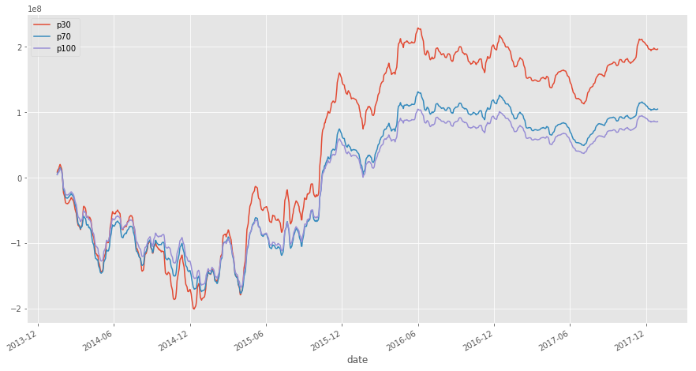

```python
# Time-Series график. Кумулятивная сумма p30, p70 и p100
X[['p30', 'p70', 'p100']].cumsum().rolling(5).mean().plot()
```

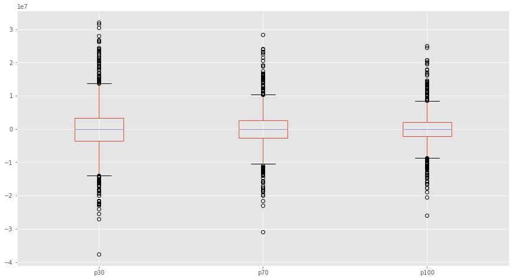

```python
# Распределения величин p30, p70 и p100. Среднее и медиана ~0
X[['p30', 'p70', 'p100']].plot.box()
```

Посчитаем корреляции между p30, p70, p100 и today_change, tomorrow_change. Скачаем историю цен и объемов:

```python
# получение дневных свечей по любой указанной бумаге используя MOEX API
def get_ohlcv(ticker, date_from, date_till):
    P = pd.DataFrame()
    # используем цикл, так как есть ограничение в выдаче значений за один запрос (max = 500)
    for i in range(5):
        url = 'http://iss.moex.com/iss/engines/stock/markets/shares/boards/tqbr/securities/' + ticker + '/candles.csv' \
        '?from=' + date_from + \
        '&till=' + date_till + \
        '&interval=24' \
        '&start=' + str(500*i)
        P = P.append(pd.read_csv(url, ';',skiprows=2))
    P['date'] = P.apply(lambda row: row['begin'][:10], axis =1)
    P['date'] = pd.to_datetime(P['date'], format = '%Y-%m-%d')
    P = P.set_index('date')

    #объем умножаем на 2, чтобы получить оборот
    P['volume'] = 2 * P['volume']
    P['value'] = 2 * P['value']

    P.drop(['begin', 'end'], axis = 1, inplace = True)
    return P
```

```python
Y = get_ohlcv(ticker, '2014-01-01', '2018-01-30')
```

```python
# change - процентное изменение цены за сегодня (close to open)
Y['today_change'] = 100 * (Y['close'] - Y['open']) / Y['open']

# tom_change - процентное изменение цены, которое будет завтра (close(+1) to сlose(0))
Y['tomorrow_change'] = 100 * Y['close'].pct_change().shift(-1)

Y.head()
```

| date | open | close | high | low | value | volume | today_change | tomorrow_change |
| --- | --- | --- | --- | --- | --- | --- | --- | --- |
| 2014-01-06 | 100.20 | 98.91 | 100.31 | 98.62 | 6.308941e+09 | 63383600 | -1.287425 | -0.727934 |
| 2014-01-08 | 99.10 | 98.19 | 99.41 | 97.85 | 8.359877e+09 | 84744580 | -0.918264 | -0.193502 |
| 2014-01-09 | 98.44 | 98.00 | 98.77 | 97.69 | 9.036778e+09 | 91973800 | -0.446973 | 1.224490 |
| 2014-01-10 | 97.87 | 99.20 | 99.41 | 97.52 | 1.021936e+10 | 103804800 | 1.358946 | 1.058468 |
| 2014-01-13 | 99.30 | 100.25 | 100.35 | 99.04 | 1.238301e+10 | 124102500 | 0.956697 | -1.007481 |

```python
# К таблице с нетто-объемом добавляем изменения цен и объемы
X = pd.merge(X, Y[['today_change', 'tomorrow_change', 'volume', 'value']], how='left', left_index = True, right_index = True)
X.head()
```

| date | p30 | p70 | p100 | oi | today_change | tomorrow_change | volume | value |
| --- | --- | --- | --- | --- | --- | --- | --- | --- |
| 2014-01-10 | 3333680 | 1310760 | 1126430 | 31124820 | 1.358946 | 1.058468 | 103804800 | 1.021936e+10 |
| 2014-01-13 | 4419280 | 3384600 | 2836260 | 39212280 | 0.956697 | -1.007481 | 124102500 | 1.238301e+10 |
| 2014-01-14 | -3718740 | -3441470 | -2529540 | 37688760 | 0.060496 | 1.541717 | 156970320 | 1.556252e+10 |
| 2014-01-15 | 8258230 | 6357870 | 5086300 | 46134300 | 0.820410 | -0.119083 | 155678740 | 1.561511e+10 |
| 2014-01-16 | 2398870 | 2589590 | 2222780 | 41385660 | -0.247770 | 0.516642 | 125518560 | 1.268416e+10 |

```
Text(0,0.5,'%')
```

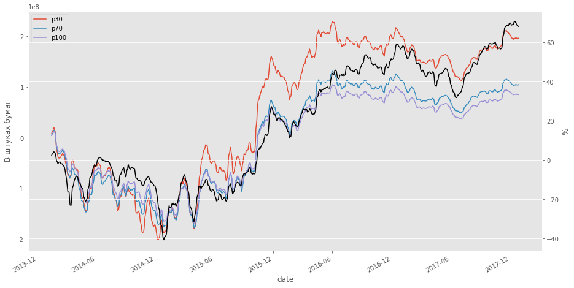

```python
# Кумулятивная сумма p30, p70, p100 (цветные линии) и движение цены - today_change (черная линия)
X[['p30', 'p70', 'p100']].cumsum().rolling(5).mean().plot()
plt.ylabel('В штуках бумаг')
X['today_change'].cumsum().rolling(5).mean().plot(secondary_y = True, c='#000000')
plt.ylabel('%')
```

Корреляции значений p30, p70, p100 с движением цены today_change и tomorrow_change на промежутке за 4 года

```python
X[['p30', 'p70', 'p100', 'today_change', 'tomorrow_change']].corr()
```

|  | p30 | p70 | p100 | today_change | tomorrow_change |
| --- | --- | --- | --- | --- | --- |
| p30 | 1.000000 | 0.983902 | 0.978002 | 0.739199 | 0.085658 |
| p70 | 0.983902 | 1.000000 | 0.995490 | 0.746328 | 0.094855 |
| p100 | 0.978002 | 0.995490 | 1.000000 | 0.753358 | 0.088971 |
| today_change | 0.739199 | 0.746328 | 0.753358 | 1.000000 | 0.070943 |
| tomorrow_change | 0.085658 | 0.094855 | 0.088971 | 0.070943 | 1.000000 |

- Сильная корреляцию между p30, p70 и p100 (~0.98)
- Cильная положительная корреляция между p30, p70, p100 и today_change (~0.75)
- Cлабая положительная корреляция между p30, p70, p100 и tomorrow_change (~0.09)

Следовательно, можно предположить, что today_change обусловлена p30, p70 и p100. А зависимость между нетто-объемом и tomorrow_change слабая, но тем не менее наблюдается стабильная положительная корреляция. Далее оценим эту зависимость.

Пробуем добиться увеличения значения корреляции между p30, p70, p100 и tomorrow_change:

1. Нормируем показатели p30, p70 и p100 на объем торгов всего рынка - VOLUME (OI, log(VOLUME) ...)
2. Посчитаем изменения p30, p70 и p100 относительно предыдущих N дней

### Создание производных показателей на основе нетто-объема

```python
Z = X.copy()
Z['p30_vol'] = 100 * Z['p30'] / Z['volume']
Z['p70_vol'] = 100 * Z['p70'] / Z['volume']
Z['p100_vol'] = 100 * Z['p100'] / Z['volume']
Z = Z.astype(float)
```

```python
Z.corr()
```

|  | p30 | p70 | p100 | oi | today_change | tomorrow_change | volume | value | p30_vol | p70_vol | p100_vol |
| --- | --- | --- | --- | --- | --- | --- | --- | --- | --- | --- | --- |
| p30 | 1.000000 | 0.983902 | 0.978002 | 0.116485 | 0.739199 | 0.085658 | 0.112916 | 0.136930 | 0.879253 | 0.879285 | 0.882764 |
| p70 | 0.983902 | 1.000000 | 0.995490 | 0.093715 | 0.746328 | 0.094855 | 0.088105 | 0.110940 | 0.854245 | 0.884921 | 0.890116 |
| p100 | 0.978002 | 0.995490 | 1.000000 | 0.094082 | 0.753358 | 0.088971 | 0.086250 | 0.111846 | 0.841797 | 0.873696 | 0.887359 |
| oi | 0.116485 | 0.093715 | 0.094082 | 1.000000 | 0.061604 | 0.088350 | 0.932113 | 0.784842 | 0.063978 | 0.058432 | 0.061230 |
| today_change | 0.739199 | 0.746328 | 0.753358 | 0.061604 | 1.000000 | 0.070943 | 0.064108 | 0.121885 | 0.685178 | 0.700282 | 0.712124 |
| tomorrow_change | 0.085658 | 0.094855 | 0.088971 | 0.088350 | 0.070943 | 1.000000 | 0.080983 | 0.082697 | 0.100420 | 0.104861 | 0.102002 |
| volume | 0.112916 | 0.088105 | 0.086250 | 0.932113 | 0.064108 | 0.080983 | 1.000000 | 0.813131 | 0.058125 | 0.050007 | 0.050755 |
| value | 0.136930 | 0.110940 | 0.111846 | 0.784842 | 0.121885 | 0.082697 | 0.813131 | 1.000000 | 0.083652 | 0.075511 | 0.079297 |
| p30_vol | 0.879253 | 0.854245 | 0.841797 | 0.063978 | 0.685178 | 0.100420 | 0.058125 | 0.083652 | 1.000000 | 0.979742 | 0.972260 |
| p70_vol | 0.879285 | 0.884921 | 0.873696 | 0.058432 | 0.700282 | 0.104861 | 0.050007 | 0.075511 | 0.979742 | 1.000000 | 0.994428 |
| p100_vol | 0.882764 | 0.890116 | 0.887359 | 0.061230 | 0.712124 | 0.102002 | 0.050755 | 0.079297 | 0.972260 | 0.994428 | 1.000000 |

При нормировании p30, p70, p100 на объем корреляция между p30_vol, p70_vol, p100_vol и tomorrow_change стала ~0.1

Посчитаем прирост (дельту) p30, p70 и p100 относительно среднего значения за 1-5 предыдущих дней:

```python
cols = ['p30', 'p70', 'p100', 'p30_vol', 'p70_vol', 'p100_vol']

for col in cols:
    for i in [1,2,3,4,5]:
        Z[col + '_' + str(i)] = Z[col] - Z[col].shift(periods=1, freq=None, axis=0).rolling(i, min_periods = 1).mean()

print('Размерность новой таблицы ' + str(Z.shape))
Z.head()
```

```
Размерность новой таблицы (1000, 41)
```

| date | p30 | p70 | p100 | oi | today_change | tomorrow_change | volume | value | p30_vol | p70_vol | ... | p70_vol_1 | p70_vol_2 | p70_vol_3 | p70_vol_4 | p70_vol_5 | p100_vol_1 | p100_vol_2 | p100_vol_3 | p100_vol_4 | p100_vol_5 |
| --- | --- | --- | --- | --- | --- | --- | --- | --- | --- | --- | --- | --- | --- | --- | --- | --- | --- | --- | --- | --- | --- |
| 2014-01-10 | 3333680.0 | 1310760.0 | 1126430.0 | 31124820.0 | 1.358946 | 1.058468 | 103804800.0 | 1.021936e+10 | 3.211489 | 1.262716 | ... | NaN | NaN | NaN | NaN | NaN | NaN | NaN | NaN | NaN | NaN |
| 2014-01-13 | 4419280.0 | 3384600.0 | 2836260.0 | 39212280.0 | 0.956697 | -1.007481 | 124102500.0 | 1.238301e+10 | 3.560992 | 2.727262 | ... | 1.464546 | 1.464546 | 1.464546 | 1.464546 | 1.464546 | 1.200275 | 1.200275 | 1.200275 | 1.200275 | 1.200275 |
| 2014-01-14 | -3718740.0 | -3441470.0 | -2529540.0 | 37688760.0 | 0.060496 | 1.541717 | 156970320.0 | 1.556252e+10 | -2.369072 | -2.192434 | ... | -4.919695 | -4.187423 | -4.187423 | -4.187423 | -4.187423 | -3.896894 | -3.296757 | -3.296757 | -3.296757 | -3.296757 |
| 2014-01-15 | 8258230.0 | 6357870.0 | 5086300.0 | 46134300.0 | 0.820410 | -0.119083 | 155678740.0 | 1.561511e+10 | 5.304661 | 4.083968 | ... | 6.276402 | 3.816554 | 3.484787 | 3.484787 | 3.484787 | 4.878654 | 2.930207 | 2.680816 | 2.680816 | 2.680816 |
| 2014-01-16 | 2398870.0 | 2589590.0 | 2222780.0 | 41385660.0 | -0.247770 | 0.516642 | 125518560.0 | 1.268416e+10 | 1.911168 | 2.063113 | ... | -2.020855 | 1.117346 | 0.523514 | 0.592735 | 0.592735 | -1.496299 | 0.943027 | 0.457172 | 0.514313 | 0.514313 |

5 rows × 41 columns

```python
# топ 10 показателей с максимальной корреляцией
cols = Z.corr()['tomorrow_change'].sort_values(ascending = False)[1:11]

#показатели, полученные на основе прироста показывают большую корреляцию
cols
```

```
p70_3         0.109256
p70_vol_3     0.108843
p70_vol_4     0.107206
p100_vol_3    0.106920
p70_vol       0.104861
p100_vol_4    0.104418
p100_3        0.103789
p70_1         0.102869
p70_vol_5     0.102313
p100_vol      0.102002
Name: tomorrow_change, dtype: float64
```

Приросты значений p30, p70 и p100 относительно предыдущих дней показали корреляцию ~0.11

Аноличные значения по другим инструментам:

| TICKER | POS vs TOD_CHG | POS vs TOM_CHG | POS/VOL vs TOM_CHG | ΔPOS/VOL vs TOM_CHG |
| --- | --- | --- | --- | --- |
| SBER | 0.75 | 0.09 | 0.10 | 0.11 |
| GAZP | 0.73 | 0.09 | 0.08 | 0.11 |
| LKOH | 0.65 | 0.08 | 0.08 | 0.13 |
| GMKN | 0.60 | 0.04 | 0.07 | 0.05 |
| MGNT | 0.60 | 0.04 | 0.07 | 0.06 |
| ROSN | 0.67 | 0.10 | 0.11 | 0.12 |
| VTBR | 0.56 | 0.10 | 0.01 | 0.06 |
| ALRS | 0.45 | 0.00 | 0.04 | 0.07 |
| SBERP | 0.50 | 0.07 | 0.10 | 0.09 |
| AFLT | 0.50 | 0.06 | 0.07 | 0.07 |

- POS vs TOD_CHG - корреляция между нетто-объемом и today_change
- POS vs TOM_CHG - корреляция между нетто-объемом и tomorrow_change
- POS/VOL vs TOM_CHG - корреляция между нетто-объемом (нормированный на объем) и tomorrow_change
- ΔPOS/VOL vs TOM_CHG - корреляция между приростом (дельтой) нетто-объема относительно предыдущих дней с tomorrow_change

На истории в 4 года оценим, что дает корреляция ~0.1

### Статистика сонаправленности нетто-объема и tomorrow_change

Среднее значение величин p30, p70, p100 и их производных находится в окресностях 0. Посчитаем статистику сонаправленности нетто-объема и tomorrow_change по дням и по величине изменения цен(%) на основе одного из показателей p70_vol_3* (корреляция с tomorrow_change ~ 0.11):

*p70 нормированный на объем и дельта относительно среднего значения предыдущих трех дней

```python
Z = Z[1:]
Z = Z[Z['tomorrow_change'] != 0]
Z['feature'] = np.sign(Z['p70_vol_3'])
Z['base'] = np.sign(Z['tomorrow_change'])
pd.crosstab(index = Z['feature'].astype(int), columns = Z['base'].astype(int))
```

| base feature | -1 | 1 |
| --- | --- | --- |
| -1 | 248 | 243 |
| 1 | 244 | 259 |

В таком же разрезе, посчитаем кумулятивную сумму процентых изменений цен в случаях сонаправленности и разнонаправленности:

```python
pd.crosstab(index = Z['feature'].astype(int), columns = Z['base'].astype(int), values = Z['tomorrow_change'].abs().astype(int), aggfunc = 'sum')
```

| base feature | -1 | 1 |
| --- | --- | --- |
| -1 | 280 | 234 |
| 1 | 190 | 325 |

* Для простоты, проценты складывались кумулятивно. Пример: Если цена менялась +2%, -1%, +1%, получаем +2%

Дневной time-series график оговоренной выше статистики (черная линия - движение цены SBER, пять цветных - накопленная статистика сонаправленности по топ 5 показателям с наибольшей корреляцией):

```
Text(0,0.5,'%')
```

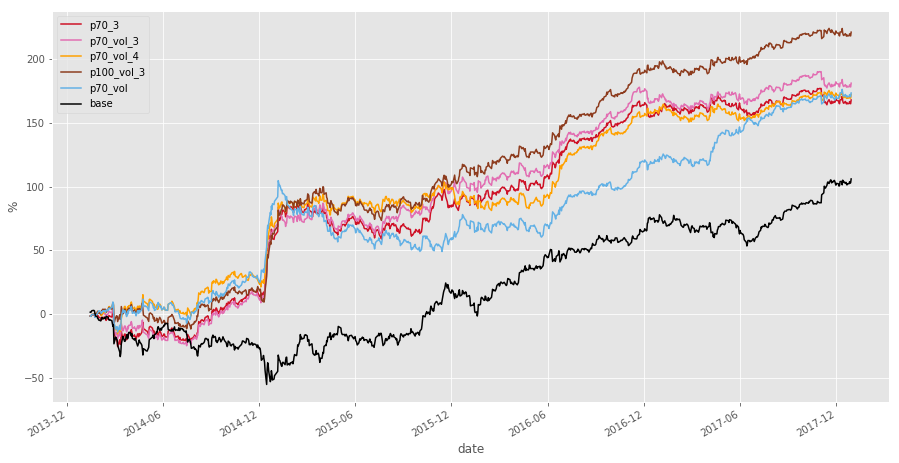

```python
R = pd.DataFrame()
for col in cols.index[:5]:
    R[col] = Z.apply(lambda x: x['tomorrow_change'] if x[col] > 0 else (-1 * x['tomorrow_change']), axis=1)
R['base'] = Z['tomorrow_change']
R.cumsum().plot(style=['#CE1126', '#E26EB2', '#FFA100', '#8D3C1E', '#63B1E5', '#000000'])
plt.ylabel('%')
```

Аналогичные графики по другим инструментам:

[figure not shown]

### Итоги

1. На примере одного инструмента (SBER) расчитали базовую статистику, распределение и динамику нетто-объемов (p30, p70, p100) крупных клентов на отрезке 2014-2017 годов
2. Сильная корреляция между нетто-объемом и today_change (~0.75) и слабая корреляция с tomorrow_change, но тем не менее положительная и стабильная (~0.1)
3. Посчитана статистика сонаправленности одного из показателей нетто-объема (p70_vol_3) c tomorrow_change (корреляция ~0.11):

[figure not shown]

### Контакты

Ссылка на сайт - [https://moex.com/ru/analyticalproducts?netflow2](https://moex.com/ru/analyticalproducts?netflow2&src=ipynb)  
Email - support.dataproducts@moex.com